# ハロプロアーティストのシングルリリース数の推移をバーチャートレースで可視化

[@anemptyarchive](https://www.anarchive-beta.com/)

2022/05/23

# シングルリリース数の推移の可視化

ハロー！プロジェクトのアーティストのシングルリリース数の推移をバーチャートレースで可視化します。

次のパッケージを利用します。

```r
# 利用パッケージ
library(tidyverse)
library(lubridate)
library(gganimate)
```

この記事では、基本的に`パッケージ名::関数名()`の記法を使うので、パッケージを読み込む必要はありません。  
ただし、パイプ演算子`%>%`を使うため`magrittr`と、作図コードがごちゃごちゃしないようにパッケージ名を省略するため`ggplot2`は読み込む必要があります。

## データの読込

「HP_DB」のデータを利用します。GitHub上のcsvデータをRから読み込めたらよかったのですがやり方が分からなかったので、ダウンロードしてローカルフォルダに保存しておきます。

保存先のフォルダパスを指定します。

```r
# フォルダパスを指定
dir_path <- "data/HP_DB-main/"
```

ファイルの読み込み時にファイル名を結合する(ファイルパスにする)ので、末尾を`/`にしておきます。

シングルの情報を読み込みます。

```r
# シングル一覧を読み込み
single_df <- readr::read_csv(
  file = paste0(dir_path, "single.csv"),
  col_types = readr::cols(
    singleID = "i",
    singleName = "c",
    releaseDate = readr::col_date(format = "%Y/%m/%d"),
    singleCategory = "c",
    artistName = "c"
  )
) %>%
  dplyr::arrange(releaseDate, singleID) # 昇順に並び替え
single_df
```

```
## # A tibble: 569 x 5
##    singleID singleName                releaseDate singleCategory      artistName
##       <int> <chr>                     <date>      <chr>               <chr>
##  1        1 愛の種                    1997-11-03  インディーズシング~ モーニン~
##  2        2 GET                       1997-11-05  シングル            平家みちよ
##  3        3 モーニングコーヒー        1998-01-28  シングル            モーニン~
##  4        4 卒業 ～TOP OF THE WORLD～ 1998-02-15  シングル            平家みちよ
##  5        5 サマーナイトタウン        1998-05-27  シングル            モーニン~
##  6        6 ダイキライ                1998-07-01  シングル            平家みちよ
##  7        7 カラスの女房              1998-08-05  シングル            中澤裕子
##  8        8 抱いてHOLD ON ME!         1998-09-09  シングル            モーニン~
##  9        9 だけど 愛しすぎて         1998-10-25  シングル            平家みちよ
## 10       10 ラストキッス              1998-11-18  シングル            タンポポ
## # ... with 559 more rows
```

single.csvは、シングルID・シングル名・リリース日・シングルカテゴリ・アーティスト名の5列のcsvファイルです。

このデータを利用して、各アーティストのシングルリリース数を集計します。

## 集計用の設定

集計に関する設定を行います。

### 期間の設定

アニメーションとしてグラフ化する(リリース数を集計する)期間を指定します。

```r
# 期間を指定
date_from <- "1997-10-01"
date_to   <- "2022-04-15"
#date_to   <- lubridate::today() %>%
#  as.character()
```

開始日を`date_from`、終了日を`date_to`として期間を指定します。文字列で`yyyy-mm-dd`や`yyyy/mm/dd`、`yyyymmdd`などと指定できます。現在の日付を使う場合は、`today()`で設定します。ただし、次の処理でベクトルにする際に`date_from, date_to`が同じ型である必要があるので、`as.character()`で文字列にしておきます。

開始日と終了日をベクトルにまとめます。

```r
# 値をまとめる
date_vals <- c(date_from, date_to) %>%
  lubridate::as_date() %>% # Date型に変換
  lubridate::floor_date(unit = "mon") # 月単位に切り捨て
date_vals
```

```
## [1] "1997-10-01" "2022-04-01"
```

文字列型で指定した開始日と終了日を、`as_date()`でDate型に変換し、さらに`floor_date()`の`unit`引数に`"mon"`を指定して月初の日付にして(日にちを切り捨てて)おきます。

### シングルカテゴリの設定

シングルのカテゴリを確認します。

```r
# シングルの種類を確認
unique(single_df[["singleCategory"]])
```

```
## [1] "インディーズシングル" "シングル"             "配信限定シングル"
## [4] "DVDシングル"          "サウンドトラック"
```

5種類のシングルがあるのが分かります。

集計に利用するカテゴリを指定します。

```r
# シングルの種類を指定
single_category <- c("インディーズシングル", "シングル")
```

この例では、インディーズシングル・シングルのリリース数を集計します。

### 連名作品の編集

続いて、アーティスト名を確認します。

```r
# アーティスト名を確認
unique(single_df[["artistName"]])[1:10]
```

```
##  [1] "モーニング娘。"     "平家みちよ"         "中澤裕子"
##  [4] "タンポポ"           "中澤ゆうこ&高山厳"  "太陽とシスコムーン"
##  [7] "中澤ゆうこ"         "ココナッツ娘"       "カントリー娘。"
## [10] "三佳千夏"
```

「Berryz工房×℃-ute」のような複数アーティストの連名作品や、「中澤ゆうこ&高山厳」のようにハロプロ以外のアーティスト名を含む作品、「カントリー娘。に石川梨華（モーニング娘。）」のようにグループ名を含む名義、「中澤ゆうこ」「モーニング娘。’14」「アンジュルム」のような名義変更や改名に対応する必要があります。  
連名作品についてはここで対応します。名義の修正は集計時に行います。

連名作品のデータを分割(複製)する際に利用するベクトルを作成します(目視で確認しながら頑張って指定します)。

```r
# 連名作品の名義を指定
pattern_vec <- c(
  "7AIR/SALT5/11WATER", "セクシーオトナジャン/エレジーズ/プリプリピンク",
  "ガーディアンズ4/しゅごキャラエッグ!", "Berryz工房×℃-ute",
  "ピーベリー/ハーベスト", #"DIY♡／GREEN FIELDS", (R Markdownだと♡でエラー)
  "ハロプロ研修生 feat. Juice=Juice",
  "ダイヤレディー／メロウクアッド／HI-FIN", "さとのあかり／トリプレット／ODATOMO",
  "カントリー・ガールズ/つばきファクトリー", "つばきファクトリー/ハロプロ研修生", "こぶしファクトリー＆つばきファクトリー"
)

# 分割後のアーティスト名を指定
replace_vec <- c(
  "7AIR", "SALT5", "11WATER", "セクシーオトナジャン", "エレジーズ", "プリプリピンク",
  "ガーディアンズ4", "しゅごキャラエッグ!", "ガーディアンズ4", "しゅごキャラエッグ!", "Berryz工房", "℃-ute", "Berryz工房", "℃-ute",
  "ピーベリー", "ハーベスト", #"DIY♡", "GREEN FIELDS",
  "ハロプロ研修生", "Juice=Juice",
  "ダイヤレディー", "メロウクアッド", "HI-FIN", "さとのあかり", "トリプレット", "ODATOMO",
  "カントリー・ガールズ", "つばきファクトリー", "つばきファクトリー", "ハロプロ研修生", "こぶしファクトリー", "つばきファクトリー"
)

# 分割する数を指定
n_vec <- c(
  3, 3,
  2, 2, 2, 2,
  2, #2,
  2,
  3, 3,
  2, 2, 2
)
```

分割する必要のあるアーティスト名を`pattern_vec`に指定します。  
分割後に設定するアーティスト名を`replace_vec`に指定します。  
分割(複製)するデータ(行)数を`n_vec`に指定します。

例えば、アーティスト名が「Berryz工房×℃-ute」のデータを「Berryz工房」と「℃-ute」の2行に分割する場合は、`pattern_vec`を`"Berryz工房×℃-ute"`・`replace_vec`を`c("Berryz工房", "℃-ute"")`・`n_vec`を`2`と指定します。  
`replace_vec`の要素数と`sum(n_vec)`が一致します。

連名作品のデータを取り出して分割します。

```r
# 連名作品を分割
split_df <- single_df %>%
  dplyr::filter(artistName %in% pattern_vec) %>% # 連名の作品を抽出
  tibble::add_column(n = n_vec) %>% # 複製数を追加
  tidyr::uncount(n) %>% # 作品を複製
  dplyr::mutate(artistName = replace_vec) # 個々のアーティスト名を再設定
split_df
```

```
## # A tibble: 30 x 5
##    singleID singleName                     releaseDate singleCategory artistName
##       <int> <chr>                          <date>      <chr>          <chr>
##  1      134 壊れない愛がほしいの/GET UP!~  2003-07-09  シングル       7AIR
##  2      134 壊れない愛がほしいの/GET UP!~  2003-07-09  シングル       SALT5
##  3      134 壊れない愛がほしいの/GET UP!~  2003-07-09  シングル       11WATER
##  4      201 オンナ、哀しい、オトナ/印象派~ 2005-06-22  シングル       セクシー~
##  5      201 オンナ、哀しい、オトナ/印象派~ 2005-06-22  シングル       エレジーズ
##  6      201 オンナ、哀しい、オトナ/印象派~ 2005-06-22  シングル       プリプリ~
##  7      338 PARTY TIME/わたしのたまご      2009-11-18  シングル       ガーディ~
##  8      338 PARTY TIME/わたしのたまご      2009-11-18  シングル       しゅごキ~
##  9      343 Going On!                      2010-01-20  シングル       ガーディ~
## 10      343 Going On!                      2010-01-20  シングル       しゅごキ~
## # ... with 20 more rows
```

`pattern_vec`に含まれるアーティストの行を`filter()`と`%in%`演算子で抽出します。  
複製する行数`n_vec`を`add_column()`で`n`列として追加して、`uncount()`で行を複製します。  
アーティスト名を`replace_vec`に指定した文字列に置き換えます。

集計時に、分割前の連名作品のデータをこのデータに置き換えます。

## リリース数の集計と順位付け

シングルのリリース数を集計してランキングを付けます。

### リリース数の集計

アーティスト名の編集を行い、アーティストごとにリリース数を集計します。

```r
# アーティスト名を編集してリリース数を集計
release_n_df <- single_df %>%
  dplyr::filter(!(artistName %in% pattern_vec)) %>% # 連名作品を削除
  dplyr::bind_rows(split_df) %>% # 分割した連名作品を追加
  dplyr::filter(singleCategory %in% single_category) %>% # 指定したカテゴリを抽出
  dplyr::filter(releaseDate >= date_vals[1], releaseDate <= date_vals[2]) %>% # 指定した期間内の作品を抽出
  dplyr::arrange(releaseDate, singleID) %>% # IDの割り当て用に昇順に並び替え
  dplyr::mutate(
    release_date = lubridate::floor_date(releaseDate, unit = "mon"), # 月単位に切り捨て
    artist_name = artistName %>% # グラフ表示名を追加
      #stringr::str_replace(pattern = "℃-ute", replacement = "C-ute") %>% # 作図時に豆腐化するので代用
      stringr::str_replace(pattern = "中澤ゆうこ&高山厳", replacement = "中澤ゆうこ") %>% # 不要な文字列を削除
      stringr::str_replace(pattern = "カントリー娘。に石川梨華（モーニング娘。）", replacement = "カントリー娘。に石川梨華") %>% # グループ名を削除
      stringr::str_replace(pattern = "カントリー娘。に紺野と藤本（モーニング娘。）", replacement = "カントリー娘。に紺野と藤本") %>% # グループ名を削除
      stringr::str_replace(pattern = "ミニハムず/プリンちゃん", replacement = "ミニハムず") %>% # 不要な文字列を削除
      stringr::str_replace(pattern = "バカ殿様とミニモニ姫。", replacement = "ミニモニ。") %>% # 企画名義を元の名前に変更
      stringr::str_replace(pattern = "ミニモニ。と高橋愛＋4KIDS", replacement = "ミニモニ。") %>% # ゲスト名を削除
      stringr::str_replace(pattern = "おけいさんと安倍なつみ", replacement = "安倍なつみ") %>% # 不要な文字列を削除
      stringr::str_replace(pattern = "あややム with エコハムず", replacement = "松浦亜弥") %>% # 企画名義を元の名前に変更
      stringr::str_replace(pattern = "DEF.DIVAと楽天イーグルス応援隊", replacement = "DEF.DIVA") %>% # 不要な文字列を削除
      stringr::str_replace(pattern = "月島きらり.*", replacement = "月島きらり(久住小春)") %>% # 長いので省略
      stringr::str_replace(pattern = "THE ポッシボー.*", replacement = "THE ポッシボー") %>% # メンバー名を削除
      stringr::str_replace(pattern = "里田まい with 藤岡藤巻", replacement = "里田まい") %>% # 不要な文字列を削除
      stringr::str_replace(pattern = "ジンギスカン×Berryz工房", replacement = "Berryz工房") %>% # 不要な文字列を削除
      stringr::str_replace(pattern = "矢口真里/エアバンド", replacement = "矢口真里") %>% # 不要な文字列を削除
      stringr::str_replace(pattern = "北神未海（CV 小川真奈）with MM学園 合唱部／氷室衣舞（声：菅谷梨沙子/Berryz工房）", replacement = "氷室衣舞(菅谷梨沙子)") %>% # 不要な文字列を削除
      stringr::str_replace(pattern = "むてん娘。", replacement = "モーニング娘。") %>% # 企画名義を元の名前に変更
      stringr::str_replace(pattern = "おはガールメープル with スマイレージ", replacement = "スマイレージ") %>% # 不要な文字列を削除
      stringr::str_replace(pattern = "NEXT YOU/Juice=Juice", replacement = "Juice=Juice") %>% # 企画名義を元の名前に変更
      stringr::str_remove(pattern = "\\(モーニング娘。'17\\)") %>% # グループ名を削除
      stringr::str_remove(pattern = "\\(アンジュルム\\)") %>% # グループ名を削除
      stringr::str_remove(pattern = "\\(Juice=Juice\\)") %>% # グループ名を削除
      stringr::str_remove(pattern = "\\(こぶしファクトリー\\)") %>% # グループ名を削除
      stringr::str_remove(pattern = "\\(つばきファクトリー\\)") %>% # グループ名を削除
      stringr::str_remove(pattern = "\\(ハロプロ研修生\\)") %>% # グループ名を削除
      stringr::str_remove(pattern = "\\(アンジュルム/カントリー・ガールズ\\)") %>% # グループ名を削除
      stringr::str_remove(pattern = "\\(LoVendoЯ\\)"), # グループ名を削除
    artist_idname = artist_name %>% # IDの割り当て用に編集
      stringr::str_replace(pattern = "^モーニング娘。.*", replacement = "モーニング娘。") %>% # ナンバリングを削除
      stringr::str_replace(pattern = "中澤ゆうこ", replacement = "中澤裕子") %>% # ソロ用名義を名前に統一
      stringr::str_replace(pattern = "T&Cボンバー", replacement = "太陽とシスコムーン") %>% # 改名前に統一
      stringr::str_replace(pattern = "カントリー娘。.*", replacement = "カントリー娘。") %>% # ゲスト名を削除
      stringr::str_replace(pattern = "ミニハムず", replacement = "ミニモニ。") %>% # 企画名義を元の名前に変更
      stringr::str_replace(pattern = "S/mileage", replacement = "スマイレージ") %>%  # 改名後に統一
      stringr::str_replace(pattern = "アンジュルム", replacement = "スマイレージ") %>% # 改名前に統一
      stringr::str_replace(pattern = "ハロプロ研修生北海道 feat.稲場愛香", replacement = "ハロプロ研修生北海道"), # ゲスト名を削除
    artist_idname = factor(artist_idname, levels = unique(artist_idname)), # レベル設定のため因子型に変換
    artist_id = dplyr::dense_rank(artist_idname) # アーティストIDを追加
  ) %>% # アーティスト名を編集
  dplyr::group_by(release_date, artist_id) %>% # カウント用にグループ化
  dplyr::mutate(release_n = dplyr::row_number()) %>% # リリース数をカウント:(count()で処理できるならしたい)
  dplyr::filter(release_n == max(release_n)) %>% # 同じ月に複数リリースしていると重複するので遅い方を採用
  dplyr::group_by(artist_id) %>% # 累積和の計算用にグループ化
  dplyr::mutate(release_n = cumsum(release_n)) %>% # リリース数の累積和を計算
  dplyr::arrange(release_date, artist_id) %>% # 複製数の追加用に並べ替え
  dplyr::group_by(artist_id) %>% # 複製数の追加用にグループ化
  dplyr::mutate(
    next_release_date = release_date %>%
      dplyr::lead(n = 1) %>% # 1行前に値をズラす
      tidyr::replace_na(
        replace = lubridate::today() %>%
          lubridate::rollforward(roll_to_first = TRUE)
      ), # 最後の行を現在の翌月にする
    n = lubridate::interval(start = release_date, end = next_release_date) %>%
      lubridate::time_length(unit = "mon") # リリース数がない期間の月数を追加
  ) %>%
  tidyr::uncount(n) %>% # 月数に応じて行を複製
  dplyr::group_by(release_date, artist_id) %>% # 行番号用にグループ化
  dplyr::mutate(idx = dplyr::row_number()) %>% # 行番号を割り当て
  dplyr::group_by(release_date, artist_id, idx) %>% # 1か月刻みの値の作成用にグループ化
  dplyr::mutate(date = seq(from = release_date, to = next_release_date, by = "mon")[idx]) %>% # 複製した行を1か月刻みの値に変更
  dplyr::ungroup() %>% # グループ化を解除
  dplyr::select(date, artist_id, artist_name, release_n) %>% # 利用する列を選択
  dplyr::arrange(date, artist_id) # 昇順に並べ替え
release_n_df
```

```
## # A tibble: 16,205 x 4
##    date       artist_id artist_name    release_n
##    <date>         <int> <chr>              <int>
##  1 1997-11-01         1 モーニング娘。         1
##  2 1997-11-01         2 平家みちよ             1
##  3 1997-12-01         1 モーニング娘。         1
##  4 1997-12-01         2 平家みちよ             1
##  5 1998-01-01         1 モーニング娘。         2
##  6 1998-01-01         2 平家みちよ             1
##  7 1998-02-01         1 モーニング娘。         2
##  8 1998-02-01         2 平家みちよ             2
##  9 1998-03-01         1 モーニング娘。         2
## 10 1998-03-01         2 平家みちよ             2
## # ... with 16,195 more rows
```

先ほどは、`pattern_vec`に指定したアーティストを`filter()`と`%in%`演算子で抽出しました。ここでは、`!`で`TRUE`と`FALSE`を入れ替えて、`pattern_vec`に含まれないアーティストのデータを抽出します。  
連名作品を除去したので、分割した連名作品`split_df`を`bind_rows()`で結合します。  
集計期間`date_vals`に発売されたデータを抽出します。

「グラフに表示する用のアーティスト名列`artist_name`」と「集計用(ID割り当て用)のアーティスト名列`artist_idname`」を作成します。  
表示名では、例えば「月島きらり starring 久住小春(モーニング娘。)」を「月島きらり(久住小春)」のように書き換えます。  
集計用名では、例えば「モーニング娘。’14」を「モーニング娘。」、「アンジュルム」を「スマイレージ」のように書き換えて、同一アーティストの名前を統一します。  
各集計用名に対して`dense_rank()`で通し番号を割り当てて、アーティストID列`artist_id`とします。  
IDの割り当て前に、`artist_idname`列を因子型に変換してレベルを設定しておくと、IDの割り当て順を指定できます。この例では、1枚目の発売が早い順(同月ならシングルIDが小さい順)になります。因子型にしない場合は、文字列の基準で昇順になります。

「発売月・ID」が同じ行ごとに`row_number()`で通し番号を割り当てて、`release_n`列とします。`release_n`列が最大の行を抽出することでリリース数列とします。(IDが同じで名義が異なる行を、同じグループとしてカウントしたかったけど、`count()`で処理できなかった？のでこんな感じになりました。)  
さらに、`cumsum()`で累積和を計算して、各月までの合計リリース数を求めます。

ここまでで、発売された月のデータを用意できました。続いて、発売のなかった月のデータを作成します。  
処理がややこしいので、下の簡単な例を使って解説します。

3か月間隔の日付を作成して、i行目とi+1行目の月数を調べます。

```r
df1 <- tibble::tibble(
  date = seq(
    from = lubridate::as_date("2020-04-01"),
    to = lubridate::as_date("2022-03-01"),
    by = "3 months"
  )
) %>%
  dplyr::mutate(
    next_date = date %>%
      dplyr::lead(n = 1) %>% # 1行前にズラす
      tidyr::replace_na(
        replace = lubridate::today() %>%
          lubridate::rollforward(roll_to_first = TRUE)
      ), # 最後の行を翌月にする
    n = lubridate::interval(start = date, end = next_date) %>%
      lubridate::time_length(unit = "month") # i行目とi+1行目の月数を追加
  )
df1
```

```
## # A tibble: 8 x 3
##   date       next_date      n
##   <date>     <date>     <dbl>
## 1 2020-04-01 2020-07-01     3
## 2 2020-07-01 2020-10-01     3
## 3 2020-10-01 2021-01-01     3
## 4 2021-01-01 2021-04-01     3
## 5 2021-04-01 2021-07-01     3
## 6 2021-07-01 2021-10-01     3
## 7 2021-10-01 2022-01-01     3
## 8 2022-01-01 2022-06-01     5
```

`seq()`の`by`引数に`"3 months"`を指定して3か月間隔の日付を作成して、発売月の代わりの列`date`とします。  
`date`列を1行前にズラした列を`lead()`で作成して、`next_date`とします。最後の行が欠損値になるので、`replace_na()`で置き換えます。`today()`と`rollfoward()`で現在の日付の翌月にします。  
`date`から`next_date`までの月数を`interval()`と`time_lenght()`で調べて、`n`列とします。

行を複製して、1か月間隔となるように日付を再設定します。

```r
df2 <- df1 %>%
  tidyr::uncount(n) %>% # 月数に応じて行を複製
  dplyr::group_by(date) %>% # 行番号用にグループ化
  dplyr::mutate(idx = dplyr::row_number()) %>% # 行番号を割り当て
  dplyr::group_by(date, idx) %>% # 1か月刻みの値の作成用にグループ化
  dplyr::mutate(new_date = seq(from = date, to = next_date, by = "month")[idx]) %>% # 複製した行を1か月刻みの値に変更
  dplyr::ungroup() # グループ化を解除
df2
```

```
## # A tibble: 26 x 4
##    date       next_date    idx new_date
##    <date>     <date>     <int> <date>
##  1 2020-04-01 2020-07-01     1 2020-04-01
##  2 2020-04-01 2020-07-01     2 2020-05-01
##  3 2020-04-01 2020-07-01     3 2020-06-01
##  4 2020-07-01 2020-10-01     1 2020-07-01
##  5 2020-07-01 2020-10-01     2 2020-08-01
##  6 2020-07-01 2020-10-01     3 2020-09-01
##  7 2020-10-01 2021-01-01     1 2020-10-01
##  8 2020-10-01 2021-01-01     2 2020-11-01
##  9 2020-10-01 2021-01-01     3 2020-12-01
## 10 2021-01-01 2021-04-01     1 2021-01-01
## # ... with 16 more rows
```

各行を`uncount()`で`n`行に複製します。  
複製した行ごとにグループ化して、`row_number()`で行番号を割り当てます。  
`date`から`next_date`の月ベクトルを作成して、行番号に応じて値を取り出します。  
ここでは分かりやすいように、作成した月列を`new_date`としました。実際には、`date`列を上書きします。

以上で、月ごとに、各アーティストの合計リリース数のデータが得られました。  
(ところで、私は2017年くらいからしか知らないのですが、解釈違いとか生じてないでしょうか？例えば、ミニモニ。とミニハムずって一緒にしていいの？、モーニング娘。おとめ組とさくら組は？)

### 演出用の処理

バーの変化(アニメーション)を強調するために、期間内における1枚目の発売1か月前のデータ(リリース数が0のデータ)を作成します。

各アーティストの「1枚目の発売1か月前」のデータフレームを作成します。

```r
# 1枚目のリリース前月のデータを作成
release_0_df <- release_n_df %>%
  dplyr::group_by(artist_id) %>% # 1枚目の抽出用にグループ化
  dplyr::filter(date == min(date)) %>% # 1枚目を抽出
  dplyr::ungroup() %>% # グループ化を解除
  dplyr::mutate(
    date = date %>%
      lubridate::rollback() %>%
      lubridate::floor_date(unit = "mon"),
    artist_name = " ",
    release_n = 0
  ) %>% # 1か月前のデータに書き換え
  dplyr::filter(date >= date_vals[1], date <= date_vals[2]) # 指定した期間内のデータを抽出
release_0_df
```

```
## # A tibble: 85 x 4
##    date       artist_id artist_name release_n
##    <date>         <int> <chr>           <dbl>
##  1 1997-10-01         1 " "                 0
##  2 1997-10-01         2 " "                 0
##  3 1998-07-01         3 " "                 0
##  4 1998-10-01         4 " "                 0
##  5 1999-03-01         5 " "                 0
##  6 1999-06-01         6 " "                 0
##  7 1999-06-01         7 " "                 0
##  8 1999-07-01         8 " "                 0
##  9 1999-10-01         9 " "                 0
## 10 2000-01-01        10 " "                 0
## # ... with 75 more rows
```

編集と集計を行ったデータ`release_n_df`から、アーティストごとに、日付列`date`が最小の行を`filter()`で抽出します。  
`date`列が1枚目の発売月になるので、`rollback()`と`floor_date()`で1か月前の日付にします。  
発売前のデータとして、アーティスト名を半角スペース`" "`、リリース数を`0`にします。  
集計期間`date_vals`内のデータを`filter()`で抽出します。

### リリース数の順位付け

各月における「リリース数」と「順位」のデータフレームを作成します。

```r
# 描画する順位を指定
max_rank <- 50

# リリース数で順位付け
rank_df <- dplyr::bind_rows(release_0_df, release_n_df) %>% # 発売前月のデータを追加:(小細工する場合)
  dplyr::arrange(date, artist_id) %>% # 昇順に並び替え
  dplyr::group_by(date) %>% # 月でグループ化
  dplyr::mutate(
    artist_id = factor(artist_id),  # 作図用に因子型に変換
    ranking = dplyr::row_number(-release_n) # ランキング列を追加
  ) %>%
  dplyr::ungroup() %>% # グループ化を解除
  dplyr::filter(ranking <= max_rank) %>% # ランク上位グループを抽出
  dplyr::arrange(date, ranking) # 昇順に並べ替え
rank_df
```

```
## # A tibble: 11,957 x 5
##    date       artist_id artist_name      release_n ranking
##    <date>     <fct>     <chr>                <dbl>   <int>
##  1 1997-10-01 1         " "                      0       1
##  2 1997-10-01 2         " "                      0       2
##  3 1997-11-01 1         "モーニング娘。"         1       1
##  4 1997-11-01 2         "平家みちよ"             1       2
##  5 1997-12-01 1         "モーニング娘。"         1       1
##  6 1997-12-01 2         "平家みちよ"             1       2
##  7 1998-01-01 1         "モーニング娘。"         2       1
##  8 1998-01-01 2         "平家みちよ"             1       2
##  9 1998-02-01 1         "モーニング娘。"         2       1
## 10 1998-02-01 2         "平家みちよ"             2       2
## # ... with 11,947 more rows
```

リリース前のデータ`release_0_df`とリリース数のデータ`release_n_df`を`bind_rows()`で結合します。  
バーの色分け用に、アーティストIDを因子型に変換します。  
`row_number()`でリリース数に応じて順位を付けて、`ranking`列とします。指定した列を昇順にして通し番号が割り当てられるので、`-`を付けて大小関係を反転させます。  
描画する順位を指定しておき、上位のデータを`filter()`で抽出します。

以上で、必要なデータを得られました。次は、作図を行います。

## 推移の可視化

リリース数と順位を棒グラフで可視化します。

### バーチャートレースの作成

シングルリリース数の推移をバーチャートレースで可視化します。バーチャートレースの作図については別資料を参照してください。

フレームに関する値を指定します。

```r
# 遷移フレーム数を指定
t <- 8

# 一時停止フレーム数を指定
s <- 2

# 1秒間に表示する月数を指定:(値が大きいと意図した通りにならない)
mps <- 3

# フレーム数を取得
n <- length(unique(rank_df[["date"]]))
n
```

```
## [1] 296
```

現月と次月のグラフを繋ぐアニメーションのフレーム数を`t`として、整数を指定します。  
各月のグラフで一時停止するフレーム数を`s`として、整数を指定します。  
基本となるフレーム数(月の数)を`n`とします。

バーチャートレースを作成します。

```r
# バーチャートレースを作成:(y軸可変)
anim <- ggplot(rank_df, aes(x = ranking, y = release_n, fill = artist_id, color = artist_id)) +
  geom_bar(stat = "identity", width = 0.9, alpha = 0.8) + # リリース数のバー
  geom_text(aes(y = 0, label = paste(artist_name, " ")), hjust = 1) + # アーティスト名のラベル
  geom_text(aes(label = paste(" ", round(release_n, 0), "枚")), hjust = 0) + # リリース数のラベル
  gganimate::transition_states(states = date, transition_length = t, state_length = s, wrap = FALSE) + # フレーム
  gganimate::ease_aes("cubic-in-out") + # アニメーションの緩急
  theme(
    axis.title.x = element_blank(), # x軸のラベル
    axis.title.y = element_blank(), # y軸のラベル
    axis.text.x = element_blank(), # x軸の目盛ラベル
    axis.text.y = element_blank(), # y軸の目盛ラベル
    axis.ticks.x = element_blank(), # x軸の目盛指示線
    axis.ticks.y = element_blank(), # y軸の目盛指示線
    #panel.grid.major.x = element_line(color = "grey", size = 0.1), # x軸の主目盛線
    panel.grid.major.y = element_blank(), # y軸の主目盛線
    #panel.grid.minor.x = element_blank(), # x軸の補助目盛線
    panel.grid.minor.y = element_blank(), # y軸の補助目盛線
    panel.border = element_blank(), # グラフ領域の枠線
    #panel.background = element_blank(), # グラフ領域の背景
    plot.title = element_text(color = "black", face = "bold", size = 20, hjust = 0.5), # 全体のタイトル
    plot.subtitle = element_text(color = "black", size = 15, hjust = 0.5), # 全体のサブタイトル
    plot.margin = margin(t = 10, r = 50, b = 10, l = 150, unit = "pt"), # 全体の余白
    legend.position = "none" # 凡例の表示位置
  ) + # 図の体裁
  coord_flip(clip = "off", expand = FALSE) + # 軸の入れ変え
  scale_x_reverse() + # x軸を反転
  gganimate::view_follow(fixed_x = TRUE) + # 表示範囲の調整
  labs(
    title = "ハロプロアーティストのシングルリリース数の推移",
    subtitle = paste0(
      "カテゴリ：［", paste0(single_category, collapse = ", "), "］\n",
      lubridate::year(date_from), "年", lubridate::month(date_from), "月～",
      "{lubridate::year(closest_state)}年{lubridate::month(closest_state)}月"
    ),
    caption = "データ:「https://github.com/xxgentaroxx/HP_DB」"
  ) # ラベル
```

`animate()`でgif画像を作成します。

```r
# gif画像を作成
g <- gganimate::animate(
  plot = anim,
  nframes = n*(t+s), fps = (t+s)*mps,
  width = 900, height = 800
)
g
```

`plot`引数にグラフ、`nframes`引数にフレーム数、`fps`引数に1秒当たりのフレーム数を指定します。

`anim_save()`でgif画像を保存します。

```r
# gif画像を保存
gganimate::anim_save(filename = "output/SingleNum.gif", animation = g)
```

`filename`引数にファイルパス(`"(保存する)フォルダ名/(作成する)ファイル名.gif"`)、`animation`引数に作成したgif画像を指定します。

動画を作成する場合は、`renderer`引数を指定します。

```r
# 動画を作成と保存
m <- gganimate::animate(
  plot = anim,
  nframes = n*(t+s), fps = (t+s)*mps,
  width = 900, height = 800,
  renderer = gganimate::av_renderer(file = "output/SingleNum.mp4")
)
```

`renderer`引数に、レンダリング方法に応じた関数を指定します。この例では、`av_renderer()`を使います。  
`av_renderer()`の`file`引数に保存先のファイルパス(`"(保存する)フォルダ名/(作成する)ファイル名.mp4"`)を指定します。

### 月を指定して作図

最後に、指定した月のリリース数のグラフを作成します。

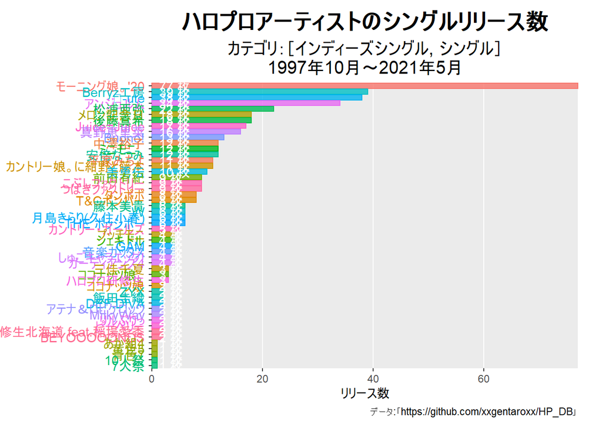

```r
# 月を指定
date_val <- "2021-05-01"

# 棒グラフを作成
graph <- rank_df %>%
  dplyr::filter(date == lubridate::as_date(date_val)) %>%
  ggplot(aes(x = ranking, y = release_n, fill = artist_id, color = artist_id)) +
  geom_bar(stat = "identity", width = 0.9, alpha = 0.8) + # リリース数のバー
  geom_text(aes(y = 0, label = paste(artist_name, " ")), hjust = 1) + # グループ名のラベル
  geom_text(aes(y = 0, label = paste(" ", release_n, "枚")), hjust = 0, color = "white") + # リリース数のラベル
  theme(
    axis.title.y = element_blank(), # y軸のラベル
    axis.text.y = element_blank(), # y軸の目盛ラベル
    #panel.grid.major.x = element_line(color = "grey", size = 0.1), # x軸の主目盛線
    panel.grid.major.y = element_blank(), # y軸の主目盛線
    panel.grid.minor.x = element_blank(), # x軸の補助目盛線
    panel.grid.minor.y = element_blank(), # y軸の補助目盛線
    panel.border = element_blank(), # グラフ領域の枠線
    #panel.background = element_blank(), # グラフ領域の背景
    plot.title = element_text(color = "black", face = "bold", size = 20, hjust = 0.5), # 全体のタイトル
    plot.subtitle = element_text(color = "black", size = 15, hjust = 0.5), # 全体のサブタイトル
    plot.margin = margin(t = 10, r = 20, b = 10, l = 125, unit = "pt"), # 全体の余白
    legend.position = "none" # 凡例の表示位置
  ) + # 図の体裁
  coord_flip(clip = "off", expand = FALSE) + # 軸の入れ変え
  scale_x_reverse(breaks = 1:max(rank_df[["ranking"]])) + # x軸を反転
  labs(
    title = "ハロプロアーティストのシングルリリース数",
    subtitle = paste0(
      "カテゴリ：［", paste0(single_category, collapse = ", "), "］\n",
      lubridate::year(date_from), "年", lubridate::month(date_from), "月～",
      lubridate::year(date_val), "年", lubridate::month(date_val), "月"
    ),
    y = "リリース数",
    caption = "データ:「https://github.com/xxgentaroxx/HP_DB」"
  ) # ラベル
graph
```

`ggsave()`で画像を保存できます。

```r
# 画像を保存
ggplot2::ggsave(
  filename = paste0("output/SingleNum_", date_val, ".png"), plot = graph,
  width = 24, height = 24, units = "cm", dpi = 100
)
```

以上で、シングルリリース数の推移を可視化できました。